# Principle 6 LANDFIRE methods

The Nature Conservancy’s LANDFIRE team

2/10/2021

## LANDFIRE and FSC Principle 6: General Potential

Principle 6 of the US Forest Stewardship Council standards (both current and draft) centers on Environmental Values and Impacts. There are several assessment criteria, with some focusing on documenting historical ecosystem attributes then comparing them to current. These criteria are where LANDFIRE products best fit.

Below we’ll explore use of LANDFIRE products for specific indicators, with the DRAFT standards as the focus.

## General

- list LANDFIRE datasets to obtain
- scale issue warning

## Criteria 6.1, Assessing Environmental Values and Impacts

From the standards document (currently page 35 in draft):

The Organization shall assess environmental values in the Management Unit and FSC® NATIONAL FOREST STEWARDSHIP STANDARD OF THE UNITED STATES (V2-0 D1-0) 36 those values outside the Management Unit potentially affected by management activities. This assessment shall be undertaken with a level of detail, scale, and frequency that is proportionate to the scale, intensity, and risk of management activities, and is sufficient for the purpose of deciding the necessary conservation measures, and for detecting and monitoring possible negative impacts of those activities.

### Indicator 6.1.1-assessment of conditions

This indicator seems to speak directly to LANDFIRE, as the suite of products can be used pretty directly to get at:

- forest community types
- succession classes
- natural disturbance regimes
- historical conditions (community types and succession classes)
- comparing historical to current conditions

#### The “recipe”

You will need these LANDFIRE products:

- Spatial datasets, clipped to your area(s) of interest
  - [Biophysical Settings](https://www.landfire.gov/bps.php). This dataset will be used to get at “community habitat”, or where ecosystems could occur based on abiotic factors (e.g., soils, climate).
  - [Succession classes](https://www.landfire.gov/sclass.php) characterizes structural classes on the landscape at the time the dataset represents (e.g., 2016 for LF Version 200).
  - [Existing Vegetation Type](https://www.landfire.gov/evt.php) maps NatureServe’s Ecological Systems (see descriptions [here](https://www.landfire.gov/documents/LANDFIRE_Ecological_Systems_Descriptions_CONUS.pdf)).
- Non-spatial products
  - [Biophysical Settings Descriptions](http://landfirereview.org/search.php) which has information on natural disturbance regimes and succession class descriptions (also available [here](https://tnc.box.com/s/d3ocvy969s1792m5885filjhktujp86e))
  - [Reference Condition Table](https://tnc.box.com/s/d3ocvy969s1792m5885filjhktujp86e) supplements the BpS descriptions with the “reference” percentages for each succession class, for each Biophysical Settings.

Methods:

1. Once spatial data is clipped to area of interest, perform a “combine” in ArcMap (Toolbox > Spatial Analyst > Local > Combine) of the BpS, SCL and EVT datasets. Alternatively, you can combine a raster of the area of interest with those 3 datasets which are stored as larger extents (like shown below).

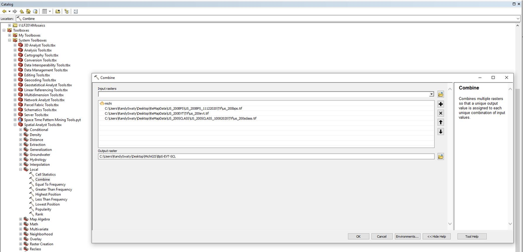

2. Join in attributes. There are multiple ways-we recommend using the Join Field tool (Toolbox > data management tools > joins > add join). One reason to do this is to be able to select which fields to join in. A potential resulting table looks like this for a landscape in Michigan (with minimal cleaning/formatting):

|  | VALUE | COUNT | BPS_NAME | BPS_MODEL | GROUPVEG | EVT_NAME | EVT_PHYS | LABEL |
| --- | --- | --- | --- | --- | --- | --- | --- | --- |
| 1 | 1 | 155604 | Open Water | na | Open Water | Open Water | Open Water | Water |
| 2 | 2 | 4217 | Laurentian-Acadian Northern Hardwoods Forest - Hemlock | 13022_41_50_51 | Hardwood | Northern &amp; Central Ruderal Meadow | Exotic Herbaceous | UE |
| 3 | 3 | 6051 | Laurentian-Acadian Northern Hardwoods Forest - Hemlock | 13022_41_50_51 | Hardwood | Laurentian Jack Pine-Red Pine Forest | Conifer | UN |
| 4 | 4 | 2285 | Laurentian-Acadian Northern Hardwoods Forest - Hemlock | 13022_41_50_51 | Hardwood | Laurentian Jack Pine-Red Pine Forest | Conifer | E |
| 5 | 5 | 2971 | Laurentian-Acadian Northern Hardwoods Forest - Hemlock | 13022_41_50_51 | Hardwood | Laurentian-Acadian Pine-Hemlock Forest | Conifer | UN |
| 6 | 6 | 5351 | Laurentian-Acadian Northern Hardwoods Forest - Hemlock | 13022_41_50_51 | Hardwood | Laurentian-Acadian Sub-boreal Mesic Balsam Fir-Spruce Forest | Conifer | UN |

As is this table does not mean too much-we will need to do some cleaning, formatting and calculating.

[output not shown]

4. Pivot table time! We are getting close to some answers! Copy the entire “clean” sheet, click “Insert” at in the Excel ribbon then click “Pivot Table”. Once your pivot table is created you can start to explore.

**First Question:** how many acres (what percent) of each ecosystem were in the area of interest historically?

1. In the Pivot Table Fields pane, select BpS Name then acres.
2. Right click in the top “Sum of ACRES” field (not the table header), then sort in descending order.
3. In our example we have some BpSs that have low ACRES values. We also have categories that are not meaningful, such as “Barren-Rock/Sand/Clay”. We can do a little formatting/cleaning before making a chart:
   - To remove BpSs from the table you will click the drop-down menu to the right of “BPS_NAME” in the Pivot Table Fields pane. You can uncheck BpSs as appropriate.
   - It is also possible to filter by right clicking on the top value in the list of BpSs, then selecting Filter > Top 10…. Once in that menu you can refine the filtering.
4. To get percentages, drag “ACRES” from the top Pivot Table Field pane to the “Values” pane. This will add a second “ACRES” column to the table. Click the drop down in the second instance of “ACRES” (reads “SUM of ACRES2” in our example), then Value Field Settings. In this menu select the “Show Values As” tab, click the “Show Values As” drop down then select “% of Grand Total% to get percentages of each BpS (make sure that”BPS_NAME" is selected as the “Base field”).
5. To get a “running total” of percentages you will add a third instance of “ACRES” to the “Values” pane, then Value Field Settings. In this menu select the “Show Values As” tab, click the “Show Values As” drop down then select “% Running Total In” to get running totals of percentages of each BpS (make sure that “BPS_NAME” is selected as the “Base field”).

Formatted table of BpSs:

|  | BpS | ACRES | PERCENT | RUNNING_PERCENT |
| --- | --- | --- | --- | --- |
| 1 | Northern Hardwoods Forest - Hemlock | 361509.018 | 50.09601316 | 50.09601316 |
| 2 | Acidic Peatland Systems | 85712.424 | 11.87757568 | 61.97358884 |
| 3 | Pine-Hemlock-Hardwood Forest | 82992.702 | 11.50069095 | 73.47427979 |
| 4 | Alkaline Conifer-Hardwood Swamp | 56369.796 | 7.811429043 | 81.28570884 |
| 5 | White Spruce-Fir-Hardwood Forest - Inland | 51340.608 | 7.114510693 | 88.40021953 |
| 6 | White Spruce-Fir-Hardwood Forest - Coastal | 41897.838 | 5.805981426 | 94.20620096 |

We see that the top 4 BpSs comprised ~80% of our example landscape historically. We can visually confirm this and other patterns with a quick chart:

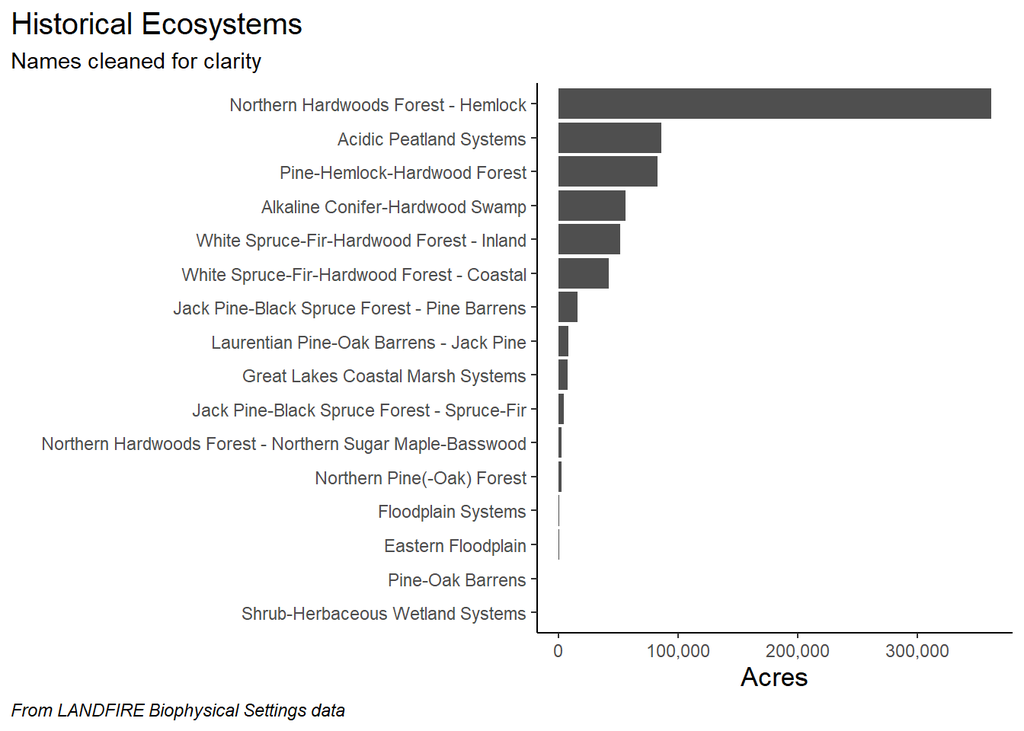

**Second Question:** How much have these (or the top 5) historical ecosystems been converted (or succeeded to) other land uses (e.g., agriculture) or ecosystems?